# Assignment 3

32437587

COVID-19 vaccines: Knowing the unknown.

2020

07

08

Vaccine development against SARS-CoV-2 has drawn attention around the globe due to the exploding pandemic. Although COVID-19 is caused by a new coronavirus, SARS-CoV-2, previous research on other coronavirus vaccines, such as FIPV, SARS, and MERS, has provided valuable information for the rapid development of COVID-19 vaccine. However, important knowledge gaps remain - some are specific to SARS-CoV-2, others are fundamental to immunology and vaccinology. Here, we discuss areas that need to be addressed for COVID-19 vaccine development, and what can be learned from examples of vaccine development in the past. Since the beginning of the outbreak, the research progress on COVID-19 has been remarkable. We are therefore optimistic about the rapid development of COVID-19 vaccine. © 2020 WILEY-VCH Verlag GmbH & Co. KGaA, Weinheim.

32434788

COVID-19 and lung cancer: risks, mechanisms and treatment interactions.

Journal for immunotherapy of cancer

2020

05

29

Cases of the 2019 novel coronavirus also known as severe acute respiratory syndrome coronavirus 2 (SARS-CoV-2) continue to rise worldwide. To date, there is no effective treatment. Clinical management is largely symptomatic, with organ support in intensive care for critically ill patients. The first phase I trial to test the efficacy of a vaccine has recently begun, but in the meantime there is an urgent need to decrease the morbidity and mortality of severe cases. It is known that patients with cancer are more susceptible to infection than individuals without cancer because of their systemic immunosuppressive state caused by the malignancy and anticancer treatments. Therefore, these patients might be at increased risk of pulmonary complications from COVID-19. The SARS-CoV-2 could in some case induce excessive and aberrant non-effective host immune responses that are associated with potentially fatal severe lung injury and patients can develop acute respiratory distress syndrome (ARDS). Cytokine release syndrome and viral ARDS result from uncontrolled severe acute inflammation. Acute lung injury results from inflammatory monocyte and macrophage activation in the pulmonary luminal epithelium which lead to a release of proinflammatory cytokines including interleukin (IL)-6, IL-1 and tumor necrosis factor-α. These cytokines play a crucial role in immune-related pneumonitis, and could represent a promising target when the infiltration is T cell predominant or there are indirect signs of high IL-6-related inflammation, such as elevated C-reactive protein. A monoclonal anti-IL-6 receptor antibody, tocilizumab has been administered in a number of cases in China and Italy. Positive clinical and radiological outcomes have been reported. These early findings have led to an ongoing randomized controlled clinical trial in China and Italy. While data from those trials are eagerly awaited, patients’ management will continue to rely for the vast majority on local guidelines. Among many other aspects, this crisis has proven that different specialists must join forces to deliver the best possible care to patients. © Author(s) (or their employer(s)) 2020. Re-use permitted under CC BY-NC. No commercial re-use. See rights and permissions. Published by BMJ.

32425638

Reducing mortality and morbidity in patients with severe COVID-19 disease by advancing ongoing trials of Mesenchymal Stromal (stem) Cell (MSC) therapy - Achieving global consensus and visibility for cellular host-directed therapies.

International journal of infectious diseases : IJID : official publication of the International Society for Infectious Diseases

2020

07

28

As of May 17th 2020, the novel coronavirus disease 2019 (COVID-19) pandemic has caused 307,395 deaths worldwide, out of 3,917,366 cases reported to the World Health Organization. No specific treatments for reducing mortality or morbidity are yet available. Deaths from COVID-19 will continue to rise globally until effective and appropriate treatments and/or vaccines are found. In search of effective treatments, the global medical, scientific, pharma and funding communities have rapidly initiated over 500 COVID-19 clinical trials on a range of antiviral drug regimens and repurposed drugs in various combinations. A paradigm shift is underway from the current focus of drug development targeting the pathogen, to advancing cellular Host-Directed Therapies (HDTs) for tackling the aberrant host immune and inflammatory responses which underlie the pathogenesis of SARS-CoV-2 and high COVID-19 mortality rates. We focus this editorial specifically on the background to, and the rationale for, the use and evaluation of mesenchymal stromal (Stem) cells (MSCs) in treatment trials of patients with severe COVID-19 disease. Currently, the ClinicalTrials.gov and the WHO Clinical Trials Registry Platform (WHO ICTRP) report a combined 28 trials exploring the potential of MSCs or their products for treatment of COVID-19. MSCs should also be trialed for treatment of other circulating WHO priority Blueprint pathogens such as MERS-CoV which causes upto 34% mortality rates. It’s about time funding agencies invested more into development MSCs per se, and also for a range of other HDTs, in combination with other therapeutic interventions. MSC therapy could turn out to be an important contribution to bringing an end to the high COVID-19 death rates and preventing long-term functional disability in those who survive disease. Copyright © 2020 The Author(s). Published by Elsevier Ltd.. All rights reserved.

32423342

COVID-19 pandemic: what can pharmaceutical formulation and drug delivery experts offer?

Pharmaceutical development and technology

2020

05

21

NA

32420637

Repurposing current therapeutics for treating COVID-19: A vital role of prescription records data mining.

Drug development research

2020

09

09

Since its outbreak in late 2019, the SARS-Cov-2 pandemic already infected over 3.7 million people and claimed more than 250,000 lives globally. At least 1 year may take for an approved vaccine to be in place, and meanwhile millions more could be infected, some with fatal outcome. Over thousand clinical trials with COVID-19 patients are already listed in ClinicalTrials.com, some of them for assessing the utility of therapeutics approved for other conditions. However, clinical trials take many months, and are typically done with small cohorts. A much faster and by far more efficient method for rapidly identifying approved therapeutics that can be repurposed for treating COVID-19 patients is data mining their past and current electronic health and prescription records for identifying drugs that may protect infected individuals from severe COVID-19 symptoms. Examples are discussed for applying health and prescription records for assessing the potential repurposing (repositioning) of angiotensin receptor blockers, estradiol, or antiandrogens for reducing COVID-19 morbidity and fatalities. Data mining of prescription records of COVID-19 patients will not cancel the need for conducting controlled clinical trials, but could substantially assist in trial design, drug choice, inclusion and exclusion criteria, and prioritization. This approach requires a strong commitment of health provides for open collaboration with the biomedical research community, as health provides are typically the sole owners of retrospective drug prescription records. © 2020 Wiley Periodicals, Inc.

32414757

Ethical considerations for epidemic vaccine trials.

Journal of medical ethics

2020

07

16

Vaccines are a powerful measure to protect the health of individuals and to combat outbreaks such as the COVID-19 pandemic. An ethical dilemma arises when one effective vaccine has been successfully developed against an epidemic disease and researchers seek to test the efficacy of another vaccine for the same pathogen in clinical trials involving human subjects. On the one hand, there are compelling reasons why it would be unethical to trial a novel vaccine when an effective product exists already. First, it is a firm principle of medical ethics that an effective treatment or vaccine should not be withheld from patients if their life may depend on it. Second, since epidemic outbreaks often emerge in settings with less-resourced health systems, there is a pronounced risk that any trial withholding an effective vaccine would disproportionately affect the vulnerable populations that historically have been exploited for biomedical research. Third, clinical trials for novel vaccines may be at odds with efforts to control active outbreaks. On the other hand, it may be justified to conduct a trial for a candidate vaccine if it is expected to have certain advantages compared with the existing product. This essay discusses key factors for comparing vaccines against epidemic pathogens, including immunological, logistical and economic considerations. Alongside a case study of the development of vaccines for Ebola, the essay seeks to establish a general framework that should be expanded and populated by immunologists, epidemiologists, economists and bioethicists, and ultimately could be applied to the case of COVID-19 vaccines. © Author(s) (or their employer(s)) 2020. No commercial re-use. See rights and permissions. Published by BMJ.

32410772

Emerging pharmacotherapies for COVID-19.

Biomedicine & pharmacotherapy = Biomedecine & pharmacotherapie

2020

06

30

Novel Corona-virus Disease 2019 (nCOVID 19) is caused by a novel virulent corona virus and leads to potentially fatal virulent pneumonia and severe respiratory distress syndrome. It was initially declared as public health emergency if international concern by WHO followed by Pandemic on 12th March 2020. As of 10th April 2020, more than 1.5 million people are affected globally with around 95,000 deaths. Vaccines for this deadly virus are currently under development and many drugs used for other indications have been repurposed and investigated for prophylaxis and treatment of COVID 19. As per SOLIDARITY trial by WHO, some of the most promising candidates include chloroquine phosphate and hydroxychloroquine which are anti-malarial medications, Remdesivir, Lopinavir-Ritonavir combination with or without interferon which are anti-HIV drugs and convalescent plasma therapy. The current evidence of efficacy and ongoing research has been elaborated in the article. Besides, there has been evidence regarding inflammatory pathogenesis of this virus leading to cytokine storm in susceptible individuals. Thus, anti-proinflammatory cytokine drugs like Anakinra and Tocilizumab are undergoing multiple trials and some results are encouraging. Similarly, use of anti-inflammatory cytokines like IL-37 and IL-38 is hypothesised to be useful and is under research. The situation is still evolving and hence there is yet no definitive therapy but to conclude the use of repurposed medications can be a boon till a definitive therapy and vaccines are developed. Copyright © 2020 The Authors. Published by Elsevier Masson SAS.. All rights reserved.

32410758

Consider pregnancy in COVID-19 therapeutic drug and vaccine trials.

Lancet (London, England)

2020

05

29

NA

32407706

SARS-CoV-2: A New Song Recalls an Old Melody.

Cell host & microbe

2020

05

18

The viruses causing the SARS outbreak of 2002-2003 and current COVID-19 pandemic are related betacoronaviruses. What insights were learned from SARS that can inform SARS-CoV-2 vaccine development? Focusing on important lessons from SARS vaccine development and two SARS vaccines evaluated in humans may guide SARS-CoV-2 vaccine design, testing, and implementation. Copyright © 2020 Elsevier Inc. All rights reserved.

32407539

Clinical Trials for COVID-19: Can we Better Use the Short Window of Opportunity?

Clinical pharmacology and therapeutics

2020

09

29

The scientific community has risen to the coronavirus disease 2019 (COVID-19) challenge, coming up with an impressive list of candidate drugs and vaccines targeting an array of pharmacological and immunological mechanisms. Yet, generating clinical evidence of efficacy and safety of these candidate treatments may be frustrated by the absence of comprehensive trial coordination mechanisms. Many small stand-alone trials and observational studies of single-agent interventions are currently running or in planning; many of these will likely not deliver robust results that could support regulatory and patient-level treatment decisions. In this paper, we discuss actions that all stakeholders in the clinical trial ecosystem need to take to ensure that the window of opportunity during this pandemic will not shut, both for patients in need of treatment and for researchers to conduct decision-relevant clinical trials. © 2020 The Authors. Clinical Pharmacology & Therapeutics published by Wiley Periodicals LLC on behalf of American Society for Clinical Pharmacology and Therapeutics.

32406317

Potential anti-viral activity of approved repurposed drug against main protease of SARS-CoV-2: an in silico based approach.

Journal of biomolecular structure & dynamics

2020

05

25

The Severe Acute Respiratory Syndrome Coronavirus 2 (SARS-CoV-2) which was first reported in Wuhan province of China, has become a deadly pandemic causing alarmingly high morbidity and mortality. In the absence of new targeted drugs and vaccines against SARS-CoV-2 at present, the choices for effective treatments are limited. Therefore, considering the exigency of the situation, we focused on identifying the available approved drugs as potential inhibitor against the promising Coronavirus drug target, the Main Protease, using computer-aided methods. We created a library of U. S. Food and Drug Administration approved anti-microbial drugs and virtually screened it against the available crystal structures of Main Protease of the virus. The study revealed that Viomycin showed the highest -CDocker energy after docking at the active site of SARS-CoV-2 Main Protease. It is noteworthy that Viomycin showed higher -CDocker energy as compared to the drugs currently under clinical trial for SARS-CoV-2 treatment viz. Ritonavir and Lopinavir. Additionally, Viomycin formed higher number of H-bonds with SARS-CoV-2 Main Protease than its co-crystallised inhibitor compound N3. Molecular dynamics simulation further showed that Viomycin embedded deeply inside the binding pocket and formed robust binding with SARS-CoV-2 Main Protease. Therefore, we propose that Viomycin may act as a potential inhibitor of the Main Protease of SARS-CoV-2. Further optimisations with the drug may support the much-needed rapid response to mitigate the pandemic.Communicated by Ramaswamy H. Sarma.

32406253

Bacillus Calmette Guérin (BCG) vaccination use in the fight against COVID-19 - what’s old is new again?

Future oncology (London, England)

2020

07

06

NA

32404020

COVID-19: The race for a vaccine.

Journal of the renin-angiotensin-aldosterone system : JRAAS

2020

06

10

NA

32393664

Hydroxychloroquine in Patients with Rheumatic Disease Complicated by COVID-19: Clarifying Target Exposures and the Need for Clinical Trials.

The Journal of rheumatology

2020

06

19

To characterize hydroxychloroquine (HCQ) exposure in patients with rheumatic disease receiving longterm HCQ compared to target concentrations with reported antiviral activity against the coronavirus disease 2019 caused by SARS-CoV-2 (COVID-19). We evaluated total HCQ concentrations in serum and plasma from published literature values, frozen serum samples from a pediatric systemic lupus erythematosus trial, and simulated concentrations using a published pharmacokinetic model during pregnancy. For each source, we compared observed or predicted HCQ concentrations to target concentrations with reported antiviral activity against SARS-CoV-2. The average total serum/plasma HCQ concentrations were below the lowest SARS-CoV-2 target of 0.48 mg/l in all studies. Assuming the highest antiviral target exposure (total plasma concentration of 4.1 mg/l), all studies had about one-tenth the necessary concentration for in vitro viral inhibition. Pharmacokinetic model simulations confirmed that pregnant adults receiving common dosing for rheumatic diseases did not achieve target exposures; however, the models predict that a dosage of 600 mg once a day during pregnancy would obtain the lowest median target exposure for most patients after the first dose. We found that the average patient receiving treatment with HCQ for rheumatic diseases, including children and non-pregnant/pregnant adults, are unlikely to achieve total serum or plasma concentrations shown to inhibit SARS-CoV-2 in vitro. Nevertheless, patients receiving HCQ long term may have tissue concentrations far exceeding that of serum/plasma. Because the therapeutic window for HCQ in the setting of SARS-CoV-2 is unknown, well-designed clinical trials that include patients with rheumatic disease are urgently needed to characterize the efficacy, safety, and target exposures for HCQ.

32393526

A strategic approach to COVID-19 vaccine R&D.

Science (New York, N.Y.)

2020

06

02

NA

32387332

Current development of COVID-19 diagnostics, vaccines and therapeutics.

Microbes and infection

2020

08

14

A novel coronavirus, designated as SARS-CoV-2, first emerged in Wuhan City, Hubei Province, China, in late December 2019. The rapidly increasing number of cases has caused worldwide panic. In this review, we describe some currently applied diagnostic approaches, as well as therapeutics and vaccines, to prevent, treat and control further outbreaks of SARS-CoV-2 infection. Copyright © 2020 Institut Pasteur. Published by Elsevier Masson SAS. All rights reserved.

32387041

COVID-19 and Moral Imperialism in Multinational Clinical Research.

Archives of medical research

2020

09

28

A TV debate in April 2020 between two French doctors regarding the benefits of testing a coronavirus vaccine in Africa where there are no masks or treatments available has led to international criticism. This case highlights a problematic ethical double standard in multinational clinical research: trials that would be considered unethical in high income countries (e.g., placebo-controlled where there is an existing treatment) are nonetheless justified in low-and-middle-income countries because the existing standards of care are less (i.e., no access to a treatment). Underlying this ethical double standard in some multinational clinical trials is a moral imperialism and persistent colonialist thinking that must be rejected. © 2020 IMSS. Published by Elsevier Inc.

32387011

Tortoises, hares, and vaccines: A cautionary note for SARS-CoV-2 vaccine development.

Vaccine

2020

05

22

NA

32381692

Combination prevention for COVID-19.

Science (New York, N.Y.)

2020

05

12

NA

32380316

Convalescent plasma in Covid-19: Possible mechanisms of action.

Autoimmunity reviews

2020

06

10

Severe acute respiratory syndrome coronavirus 2 (SARS-CoV-2) is responsible of the coronavirus disease 2019 (COVID-19) pandemic. Therapeutic options including antimalarials, antivirals, and vaccines are under study. Meanwhile the current pandemic has called attention over old therapeutic tools to treat infectious diseases. Convalescent plasma (CP) constitutes the first option in the current situation, since it has been successfully used in other coronaviruses outbreaks. Herein, we discuss the possible mechanisms of action of CP and their repercussion in COVID-19 pathogenesis, including direct neutralization of the virus, control of an overactive immune system (i.e., cytokine storm, Th1/Th17 ratio, complement activation) and immunomodulation of a hypercoagulable state. All these benefits of CP are expected to be better achieved if used in non-critically hospitalized patients, in the hope of reducing morbidity and mortality. Copyright © 2020 The Author(s). Published by Elsevier B.V. All rights reserved.

32378805

COVID-19 and toxicity from potential treatments: Panacea or poison.

Emergency medicine Australasia : EMA

2020

08

05

Since December 2019, coronavirus disease (COVID-19) has been increasingly spreading from its origin in Wuhan, China to many countries around the world eventuating in morbidity and mortality affecting millions of people. This pandemic has proven to be a challenge given that there is no immediate cure, no vaccine is currently available and medications or treatments being used are still undergoing clinical trials. There have already been examples of self-medication and overdose. Clearly, there is a need to further define the efficacy of treatments used in the management of COVID-19. This evidence needs to be backed by large randomised-controlled clinical trials. In the meantime, there will no doubt be further off-label use of these medications by patients and practitioners and possibly related toxicity. © 2020 Australasian College for Emergency Medicine.

32376359

Design of a peptide-based subunit vaccine against novel coronavirus SARS-CoV-2.

Microbial pathogenesis

2020

06

18

Coronavirus disease 2019 (COVID-19) is an emerging infectious disease that was first reported in Wuhan, China, and has subsequently spread worldwide. In the absence of any antiviral or immunomodulatory therapies, the disease is spreading at an alarming rate. A possibility of a resurgence of COVID-19 in places where lockdowns have already worked is also developing. Thus, for controlling COVID-19, vaccines may be a better option than drugs. An mRNA-based anti-COVID-19 candidate vaccine has entered a phase 1 clinical trial. However, its efficacy and potency have to be evaluated and validated. Since vaccines have high failure rates, as an alternative, we are presenting a new, designed multi-peptide subunit-based epitope vaccine against COVID-19. The recombinant vaccine construct comprises an adjuvant, cytotoxic T-lymphocyte (CTL), helper T-lymphocyte (HTL), and B-cell epitopes joined by linkers. The computational data suggest that the vaccine is non-toxic, non-allergenic, thermostable, with the capability to elicit a humoral and cell-mediated immune response. The stabilization of the vaccine construct is validated with molecular dynamics simulation studies. This unique vaccine is made up of 33 highly antigenic epitopes from three proteins that have a prominent role in host-receptor recognition, viral entry, and pathogenicity. We advocate this vaccine must be synthesized and tested urgently as a public health priority. Copyright © 2020 Elsevier Ltd. All rights reserved.

32366816

An Evidence Based Perspective on mRNA-SARS-CoV-2 Vaccine Development.

Medical science monitor : international medical journal of experimental and clinical research

2020

05

06

The first outbreak of coronavirus disease 2019 (COVID-19) caused by the severe acute respiratory syndrome coronavirus 2 (SARS-CoV-2) occurred in Wuhan, Hubei Province, China, in late 2019. The subsequent COVID-19 pandemic rapidly affected the health and economy of the world. The global approach to the pandemic was to isolate populations to reduce the spread of this deadly virus while vaccines began to be developed. In March 2020, the first phase I clinical trial of a novel lipid nanoparticle (LNP)-encapsulated mRNA-based vaccine, mRNA-1273, which encodes the spike protein (S protein) of SARS-CoV-2, began in the United States (US). The production of mRNA-based vaccines is a promising recent development in the production of vaccines. However, there remain significant challenges in the development and testing of vaccines as rapidly as possible to control COVID-19, which requires international collaboration. This review aims to describe the background to the rationale for the development of mRNA-based SARS-CoV-2 vaccines and the current status of the mRNA-1273 vaccine.

32365191

Balancing Expediency and Scientific Rigor in Severe Acute Respiratory Syndrome Coronavirus 2 Vaccine Development.

The Journal of infectious diseases

2020

07

07

NA

32359402

Considering BCG vaccination to reduce the impact of COVID-19.

Lancet (London, England)

2020

05

19

NA

32355008

COVID-19 shot protects monkeys.

Science (New York, N.Y.)

2020

05

05

NA

32350686

Anti COVID-19 Drugs: Need for More Clinical Evidence and Global Action.

Advances in therapy

2020

06

09

The World Health Organization (WHO) called the outbreak of coronavirus infectious disease-2019 (COVID-19) a “Public Health Emergency of International Concern” (PHEIC). According to the WHO, Centers for Disease Control and Prevention (CDC), and the US Food and Drug Administration (FDA), currently there are no medicines or vaccines that have been claimed to be useful in the prevention or treatment of COVID-19. Several existing antiviral drugs, previously developed or used as treatments for severe acute respiratory syndrome (SARS), Middle East respiratory syndrome (MERS), human immunodeficiency virus (HIV), and malaria, are being investigated as COVID-19 treatments and some of them are being used in clinical trials. According to the CDC and Chinese treatment guidelines for COVID-19, chloroquine, hydroxychloroquine, lopinavir/ritonavir, and one of the investigational agents (remdesivir) are recommended in critically ill older patients. The use of other potential drugs reported in different studies may be considered if treatment with first-line drugs is ineffective. There are currently no complete data available from large randomized clinical trials (RCTs) to provide clinical guidance on the use, dosing, or duration to validate the effective role, safety profile, and adverse effects of all of the trial drugs for prophylaxis or treatment of COVID-19. Until now, it is still unclear which drug can successfully fight against the disease. Therefore, for the better safety of patients with COVID-19, further clinical trials and large randomized controlled studies are needed to validate the effective role, safety profile, and adverse effects of all the potential drugs. Such a measure requires action at the global level.

32348598

Review article: prevention, diagnosis and management of COVID-19 in the IBD patient.

Alimentary pharmacology & therapeutics

2020

06

22

The current COVID-19 pandemic, caused by SARS-CoV-2, has emerged as a public health emergency. All nations are seriously challenged as the virus spreads rapidly across the globe with no regard for borders. The primary management of IBD involves treating uncontrolled inflammation with most patients requiring immune-based therapies. However, these therapies may weaken the immune system and potentially place IBD patients at increased risk of infections and infectious complications including those from COVID-19. To summarise the scale of the COVID-19 pandemic, review unique concerns regarding IBD management and infection risk during the pandemic and assess COVID-19 management options and drug interactions in the IBD population. A literature review on IBD, SARS-CoV-2 and COVID-19 was undertaken and relevant literature was summarised and critically examined. IBD patients do not appear to be more susceptible to SARS-CoV-2 infection and there is no evidence of an association between IBD therapies and increased risk of COVID-19. IBD medication adherence should be encouraged to prevent disease flare but where possible high-dose systemic corticosteroids should be avoided. Patients should exercise social distancing, optimise co-morbidities and be up to date with influenza and pneumococcal vaccines. If a patient develops COVID-19, immune suppressing medications should be withheld until infection resolution and if trial medications for COVID-19 are being considered, potential drug interactions should be checked. IBD patient management presents a challenge in the current COVID-19 pandemic. The primary focus should remain on keeping bowel inflammation controlled and encouraging medication adherence. © 2020 John Wiley & Sons Ltd.

32346094

COVID-19 vaccine design: the Janus face of immune enhancement.

Nature reviews. Immunology

2020

06

15

NA

32344202

Impact of immune enhancement on Covid-19 polyclonal hyperimmune globulin therapy and vaccine development.

EBioMedicine

2020

05

29

The pandemic spread of a novel coronavirus - SARS coronavirus-2 (SARS-CoV-2) as a cause of acute respiratory illness, named Covid-19, is placing the healthcare systems of many countries under unprecedented stress. Global economies are also spiraling towards a recession in fear of this new life-threatening disease. Vaccines that prevent SARS-CoV-2 infection and therapeutics that reduces the risk of severe Covid-19 are thus urgently needed. A rapid method to derive antiviral treatment for Covid-19 is the use of convalescent plasma derived hyperimmune globulin. However, both hyperimmune globulin and vaccine development face a common hurdle - the risk of antibody-mediated disease enhancement. The goal of this review is to examine the body of evidence supporting the hypothesis of immune enhancement that could be pertinent to Covid-19. We also discuss how this risk could be mitigated so that both hyperimmune globulin and vaccines could be rapidly translated to overcome the current global health crisis. Copyright © 2020 The Author(s). Published by Elsevier B.V. All rights reserved.

32343658

Medication for COVID-19-an Overview of Approaches Currently Under Study.

Deutsches Arzteblatt international

2020

05

01

With the worldwide spread of SARS-CoV-2 infection, it is becoming increasingly urgent to develop a vaccine to prevent COVID-19, as well as effective drugs to treat it. This article is based on a selective literature search in PubMed and ClinicalTrials.gov, followed by an assessment of the ongoing clinical trials that were revealed by the search. A number of substances have been found to prevent the reproduction of SARS-CoV-2 in vitro. These include virustatic agents that have already been approved for the treatment of other types of viral infection, as well as drugs that are currently used for entirely different purposes. High in vitro activity has been found for the nucleotide analogue remdesivir, for the antimalarial drug chloroquine, and for nitazoxanide, a drug used to treat protozoan infections. Because the virus enters human cells by way of the membrane-associated angiotensin converting enzyme 2 (ACE2), keeping the virus from docking to this receptor is a conceivable treatment approach. Transmembrane protease serine 2 (TMPRSS2) plays a role in the fusion of the virus with cells; inhibitors of this enzyme are known as well. The potential therapeutic efficacy and tolerability of these and other active substances remain to be investigated in clinical trials. At present, more than 80 trials on COVID-10 have already been registered with Clinical- Trials.gov. Some initial findings should already be available in late April 2020. Clinical trials are now indispensable in order to determine the true clinical benefits and risks of the substances that have been found to be active against SARSCoV- 2 in vitro. There is not yet any recommendation for the therapeutic use of any particular agent beyond standard supportive treatment.

32341531

Could BCG be used to protect against COVID-19?

Nature reviews. Urology

2020

06

16

NA

32338347

COVID-19 in Children: Clinical Approach and Management.

Indian journal of pediatrics

2020

05

19

COVID-19 pandemic caused by severe acute respiratory syndrome coronavirus 2 (SARS-CoV-2) is a major public health crisis threatening humanity at this point in time. Transmission of the infection occurs by inhalation of infected droplets or direct contact with soiled surfaces and fomites. It should be suspected in all symptomatic children who have undertaken international travel in the last 14 d, all hospitalized children with severe acute respiratory illness, and asymptomatic direct and high-risk contacts of a confirmed case. Clinical symptoms are similar to any acute respiratory viral infection with less pronounced nasal symptoms. Disease seems to be milder in children, but situation appears to be changing. Infants and young children had relatively more severe illness than older children. The case fatality rate is low in children. Diagnosis can be confirmed by Reverse transcriptase - Polymerase chain reaction (RT-PCR) on respiratory specimen (commonly nasopharyngeal and oropharyngeal swab). Rapid progress is being made to develop rapid diagnostic tests, which will help ramp up the capacity to test and also reduce the time to getting test results. Management is mainly supportive care. In severe pneumonia and critically ill children, trial of hydroxychloroquine or lopinavir/ritonavir should be considered. As per current policy, children with mild disease also need to be hospitalized; if this is not feasible, these children may be managed on ambulatory basis with strict home isolation. Pneumonia, severe disease and critical illness require admission and aggressive management for acute lung injury and shock and/or multiorgan dysfunction, if present. An early intubation is preferred over non-invasive ventilation or heated, humidified, high flow nasal cannula oxygen, as these may generate aerosols increasing the risk of infection in health care personnel. To prevent post discharge dissemination of infection, home isolation for 1-2 wk may be advised. As of now, no vaccine or specific chemotherapeutic agents are approved for children.

32330122

Panic prescribing has become omnipresent during the COVID-19 pandemic.

The Journal of clinical investigation

2020

06

11

NA

32320592

Audio Interview: Approaches to Covid-19 Vaccines and Antivirals.

The New England journal of medicine

2020

04

27

NA

32318706

Multicenter initial guidance on use of antivirals for children with COVID-19/SARS-CoV-2.

Journal of the Pediatric Infectious Diseases Society

2020

05

14

Although Coronavirus Disease 2019 (COVID-19) is mild in nearly all children, a small proportion of pediatric patients develops severe or critical illness. Guidance is therefore needed regarding use of agents with potential activity against severe acute respiratory syndrome coronavirus 2 in pediatrics. A panel of pediatric infectious diseases physicians and pharmacists from 18 geographically diverse North American institutions was convened. Through a series of teleconferences and web-based surveys, a set of guidance statements was developed and refined based on review of best available evidence and expert opinion. Given the typically mild course of pediatric COVID-19, supportive care alone is suggested for the overwhelming majority of cases. The panel suggests a decision-making framework for antiviral therapy that weighs risks and benefits based on disease severity as indicated by respiratory support needs, with consideration on a case-by-case basis of potential pediatric risk factors for disease progression. If an antiviral is used, the panel suggests remdesivir as the preferred agent. Hydroxychloroquine could be considered for patients who are not candidates for remdesivir or when remdesivir is not available. Antivirals should preferably be used as part of a clinical trial if available. Antiviral therapy for COVID-19 is not necessary for the great majority of pediatric patients. For those rare children who develop severe or critical disease, this guidance offer an approach for decision-making regarding antivirals, informed by available data. As evidence continues to evolve rapidly, the need for updates to the guidance is anticipated. © The Author(s) 2020. Published by Oxford University Press on behalf of The Journal of the Pediatric Infectious Diseases Society. All rights reserved. For permissions, please e-mail: journals.permissions@oup.com.

32313823

One month of the novel coronavirus 2019 outbreak: Is it still a threat?

Virusdisease

2020

09

28

The novel coronavirus 2019 disease (COVID-19) is now in an outbreak not only in China but also around the world, suspected to be originated from a wet market in Wuhan, Hubei province, China. The flare-up of COVID-19, it has already been infected 78,811 people with 2462 fatalities in 1 month window. The most alarming issue is the virus can transmit from host to host and still asymptomatic. Currently, 24 counties with 505 confirmed cases have been reported. Presently, there is no specific treatment or vaccine but physicians are battling with the use of antibiotics, steroid, anti-viral and anti-HIV drugs and some of the infected cases are testified improved. WHO and China National health Commission are cooperatively striving to come up with elucidation but it will take a minimum of 3 to 4 months at least to undergo a phase-1 trial. However, the soaring rates of spreading each day has become much stable which might even improve within the next few weeks in China but not for some other countries. Healthy peoples are instructed to avoid public gathering, always wearing the mask and frequently wash hands. Currently, China has able to hold up more than 97.7% infection within China but a scientific breakthrough is crucial before it’s too late. © Indian Virological Society 2020.

32306836

Novel 2019 coronavirus structure, mechanism of action, antiviral drug promises and rule out against its treatment.

Journal of biomolecular structure & dynamics

2020

05

06

In the past two decades, the world has faced several infectious disease outbreaks. Ebola, Influenza A (H1N1), SARS, MERS, and Zika virus have had a massive global impact in terms of economic disruption, the strain on local and global public health. Most recently, the global outbreak of novel coronavirus 2019 (SARS-CoV-2) that causes COVID-19 is a newly discovered virus from the coronavirus family in Wuhan city, China, known to be a great threat to the public health systems. As of 15 April 2020, The Johns Hopkins University estimated that the COVID-19 affected more than two million people, resulting in a death toll above 130,000 around the world. Infected people in Europe and America correspond about 40% and 30% of the total reported cases respectively. At this moment only few Asian countries have controlled the disease, but a second wave of new infections is expected. Predicting inhibitor and target to the COVID-19 is an urgent need to protect human from the disease. Therefore, a protocol to identify anti-COVID-19 candidate based on computer-aided drug design is urgently needed. Thousands of compounds including approved drugs and drugs in the clinical trial are available in the literature. In practice, experimental techniques can measure the time and space average properties but they cannot be captured the structural variation of the COVID-19 during the interaction of inhibitor. Computer simulation is particularly suitable to complement experiments to elucidate conformational changes at the molecular level which are related to inhibition process of the COVID-19. Therefore, computational simulation is essential tool to elucidate the phenomenon. The structure-based virtual screening computational approach will be used to filter the best drugs from the literature, the investigate the structural variation of COVID-19 with the interaction of the best inhibitor is a fundamental step to design new drugs and vaccines which can combat the coronavirus. This mini-review will address novel coronavirus structure, mechanism of action, and trial test of antiviral drugs in the lab and patients with COVID-19.

32305089

Sarah Gilbert: carving a path towards a COVID-19 vaccine.

Lancet (London, England)

2020

04

28

NA

32304435

The Impact of the COVID-19 Pandemic on Cancer Patients.

American journal of clinical oncology

2020

06

04

In December 2019, a novel coronavirus called severe acute respiratory syndrome coronavirus 2 (SARS-CoV-2) caused an outbreak of coronavirus disease 2019 (COVID-19). Severe complications have been reported to occur in 33% of patients with COVID-19 and include acute respiratory distress syndrome, acute renal failure, acute respiratory injury, septic shock, and severe pneumonia. Currently, there is no specific treatment or approved vaccine against COVID-19 and many clinical trials are currently investigating potential medications to treat COVID-19. The immunosuppressed status of some cancer patients (whether caused by the disease itself or the treatment) increases their risk of infection compared with the general population. This short review aims to focus on the impact of COVID-19 on a cancer patient and discuss management options and recommendation in addition to highlighting the currently available clinical guidelines and resources.

32303704

The race against COVID-19.

Nature nanotechnology

2020

04

23

NA

32302280

Brief Summary of Potential SARS-CoV-2 Prophylactic and Treatment Drugs in the Emergency Department.

The western journal of emergency medicine

2020

05

21

As of March 30th, 2020 there were 161,807 total cases and 2,953 total deaths of SARS-CoV-2 in the United States, with the number of cases expected to rise. Other than supportive care, there are no SARS-CoV-2 specific treatments available for patients discharged from the emergency department (ED) or those admitted to the hospital. In addition, there are no vaccines available to protect our at-risk healthcare workers. The National Institutes of Health is conducting a Phase 1 clinical trial to evaluate for a potential vaccine and the recipients have started to receive the investigational vaccine.2 We present a brief overview of the potential prophylactic and treatment agents under investigation, some which could be initiated in the ED if proven effective.

32300051

Insights from immuno-oncology: the Society for Immunotherapy of Cancer Statement on access to IL-6-targeting therapies for COVID-19.

Journal for immunotherapy of cancer

2020

04

21

NA

32297723

COVID-2019: update on epidemiology, disease spread and management.

Monaldi archives for chest disease = Archivio Monaldi per le malattie del torace

2020

04

20

With each passing day, more cases of Coronavirus disease (COVID-2019) are being detected and unfortunately the fear of novel corona virus 2019 (2019-nCoV) becoming a pandemic disease has come true. Constant efforts at individual, national, and international level are being made in order to understand the genomics, hosts, modes of transmission and epidemiological link of nCoV-2019. As of now, whole genome sequence of the newly discovered coronavirus has already been decoded. Genomic characterization nCoV-2019 have shown close homology with bat-derived severe acute respiratory syndrome (SARS)-like coronaviruses, bat-SL-CoVZC45 and bat-SL-CoVZXC21. Structural analysis of the receptor binding site has confirmed that 2019-nCoV binds with the same ACE 2 receptor protein as human SARS virus. Compared to the previous coronavirus outbreaks, the overall mortality rate is relatively low for COVID-2019 (2-3%). Suspected cases must be quarantined till their test comes positive or they clear infection. At present, treatment of COVID-2019 is mostly based on the knowledge gained from the SARS and MERS outbreaks. Remdesivir, originally develop as a treatment for Ebola virus disease and Marburg virus infections, is being studied for it effectiveness against 2019-nCoV infection. Many other antiviral agents and vaccines are being tested but most of them are in phase I or II and hence unlikely to be of any benefit immediately with regards to current outbreak. Hence, the standard infection control techniques and preventive steps for healthy individuals and supportive care for the confirmed cases is the best available strategy to deal with current viral outbreak. .

32295694

COVID-19 vaccination clinical trials should consider multiple doses of BCG.

Die Pharmazie

2020

04

20

NA

32292113

Stem Cell-Based Therapy for Coronavirus Disease 2019.

Stem cells and development

2020

06

15

The novel coronavirus disease 2019 (COVID-19) has grown to be a global public-health emergency since patients were first detected in Wuhan, China, in December 2019. As of April 9, 2020, the novel coronavirus (named as SARS-CoV-2 by the International Committee on Taxonomy of Viruses on February 11) has infected 83,251 and 1,484,811 patients in China and the world, respectively. However, we have neither confirmed effective antiviral medications nor vaccines available to deal with this emergency. In this commentary, we offer an alternative promising therapy for COVID-19, that is, mesenchymal stem cell transplantation.

32290293

A Review of SARS-CoV-2 and the Ongoing Clinical Trials.

International journal of molecular sciences

2020

04

16

The sudden outbreak of 2019 novel coronavirus (2019-nCoV, later named SARS-CoV-2) in Wuhan, China, which rapidly grew into a global pandemic, marked the third introduction of a virulent coronavirus into the human society, affecting not only the healthcare system, but also the global economy. Although our understanding of coronaviruses has undergone a huge leap after two precedents, the effective approaches to treatment and epidemiological control are still lacking. In this article, we present a succinct overview of the epidemiology, clinical features, and molecular characteristics of SARS-CoV-2. We summarize the current epidemiological and clinical data from the initial Wuhan studies, and emphasize several features of SARS-CoV-2, which differentiate it from SARS-CoV and Middle East respiratory syndrome coronavirus (MERS-CoV), such as high variability of disease presentation. We systematize the current clinical trials that have been rapidly initiated after the outbreak of COVID-19 pandemic. Whereas the trials on SARS-CoV-2 genome-based specific vaccines and therapeutic antibodies are currently being tested, this solution is more long-term, as they require thorough testing of their safety. On the other hand, the repurposing of the existing therapeutic agents previously designed for other virus infections and pathologies happens to be the only practical approach as a rapid response measure to the emergent pandemic, as most of these agents have already been tested for their safety. These agents can be divided into two broad categories, those that can directly target the virus replication cycle, and those based on immunotherapy approaches either aimed to boost innate antiviral immune responses or alleviate damage induced by dysregulated inflammatory responses. The initial clinical studies revealed the promising therapeutic potential of several of such drugs, including favipiravir, a broad-spectrum antiviral drug that interferes with the viral replication, and hydroxychloroquine, the repurposed antimalarial drug that interferes with the virus endosomal entry pathway. We speculate that the current pandemic emergency will be a trigger for more systematic drug repurposing design approaches based on big data analysis.

32282303

Coronavirus Disease (COVID-19) Pandemic: A Race Against Time.

Current topics in medicinal chemistry

2020

08

05

NA

32282038

The VACCINES Act: Deciphering Vaccine Hesitancy in the Time of COVID-19.

Clinical infectious diseases : an official publication of the Infectious Diseases Society of America

2020

08

05

Since the COVID-19 pandemic first hit Wuhan, China, in December 2019, scientists have been racing to develop and test novel vaccines to protect against severe acute respiratory syndrome coronavirus 2 (SARS-CoV-2). The speed of scientific discovery related to COVID-19 is unprecedented. With several vaccine candidates already being tested in clinical trials, we pose the question: what will the vaccine hesitant do in the face of this pandemic? © The Author(s) 2020. Published by Oxford University Press for the Infectious Diseases Society of America.

32273621

If a coronavirus vaccine arrives, can the world make enough?

Nature

2020

04

30

NA

32273591

The COVID-19 vaccine development landscape.

Nature reviews. Drug discovery

2020

05

06

NA

32259480

SARS-CoV-2 Vaccines: Status Report.

Immunity

2020

04

24

SARS-CoV-2, the causal agent of COVID-19, first emerged in late 2019 in China. It has since infected more than 870,000 individuals and caused more than 43,000 deaths globally. Here, we discuss therapeutic and prophylactic interventions for SARS-CoV-2 with a focus on vaccine development and its challenges. Vaccines are being rapidly developed but will likely come too late to affect the first wave of a potential pandemic. Nevertheless, critical lessons can be learned for the development of vaccines against rapidly emerging viruses. Importantly, SARS-CoV-2 vaccines will be essential to reducing morbidity and mortality if the virus establishes itself in the population. Copyright © 2020 Elsevier Inc. All rights reserved.

32251618

Current Drugs with Potential for Treatment of COVID-19: A Literature Review.

Journal of pharmacy & pharmaceutical sciences : a publication of the Canadian Society for Pharmaceutical Sciences, Societe canadienne des sciences pharmaceutiques

2020

04

13

SARS-CoV-2 first emerged in China in December 2019 and rapidly spread worldwide. No vaccine or approved drug is available to eradicate the virus, however, some drugs that are indicated for other afflictions seems to be potentially beneficial to treat the infection albeit without unequivocal evidence. The aim of this article is to review the published background on the effectiveness of these drugs against COVID-19 Methods: A thorough literature search was conducted on recently published studies which have published between January 1 to March 25, 2020. PubMed, Google Scholar and Science Direct databases were searched Results: A total 22 articles were found eligible. 8 discuss about treatment outcomes from their applied drugs during treatment of COVID-19 patients, 4 report laboratory tests, one report animal trial and other 9 articles discuss recommendations and suggestions based on the treatment process and clinical outcomes of other diseases such as malaria, ebola, severe acute respiratory syndrome (SARS) and Middle East respiratory syndrome (MERS). The data and/or recommendations are categorized in 4 classes: (a) anti-viral and anti-inflammatory drugs, (b) anti-malaria drugs, (c) traditional Chinese drugs and (d) other treatments/drugs. All examined treatments, although potentiality effective against COVID-19, need either appropriate drug development or clinical trial to be suitable for clinical use.

32247193

Guidance for the management of myasthenia gravis (MG) and Lambert-Eaton myasthenic syndrome (LEMS) during the COVID-19 pandemic.

Journal of the neurological sciences

2020

04

28

NA

32243270

Potential therapeutic agents against COVID-19: What we know so far.

Journal of the Chinese Medical Association : JCMA

2020

06

16

The emerging outbreak of coronavirus disease 2019 (COVID-19) caused by the severe acute respiratory syndrome coronavirus 2 continues to spread all over the world. Agents or vaccines of proven efficacy to treat or prevent human coronavirus infection are in urgent need and are being investigated vigorously worldwide. This review summarizes the current evidence of potential therapeutic agents, such as lopinavir/ritonavir, remdesivir, favipiravir, chloroquine, hydroxychloroquine, interferon, ribavirin, tocilizumab, and sarilumab. More clinical trials are being conducted for further confirmation of the efficacy and safety of these agents in treating COVID-19.

32241928

Vaccine designers take first shots at COVID-19.

Science (New York, N.Y.)

2020

04

07

NA

32234468

The epidemiology, diagnosis and treatment of COVID-19.

International journal of antimicrobial agents

2020

05

28

In December 2019, the outbreak of the novel coronavirus disease (COVID-19) in China spread worldwide, becoming an emergency of major international concern. SARS-CoV-2 infection causes clusters of severe respiratory illness similar to severe acute respiratory syndrome coronavirus. Human-to-human transmission via droplets, contaminated hands or surfaces has been described, with incubation times of 2-14 days. Early diagnosis, quarantine, and supportive treatments are essential to cure patients. This paper reviews the literature on all available information about the epidemiology, diagnosis, isolation and treatments of COVID-19. Treatments, including antiviral agents, chloroquine and hydroxychloroquine, corticosteroids, antibodies, convalescent plasma transfusion and vaccines, are discussed in this article. In addition, registered trials investigating treatment options for COVID-19 infection are listed. Copyright © 2020 Elsevier Ltd. All rights reserved.

32232474

Human Challenge Studies to Accelerate Coronavirus Vaccine Licensure.

The Journal of infectious diseases

2020

05

19

Controlled human challenge trials of SARS-CoV-2 vaccine candidates could accelerate the testing and potential rollout of efficacious vaccines. By replacing conventional phase 3 testing of vaccine candidates, such trials may subtract many months from the licensure process, making efficacious vaccines available more quickly. Obviously, challenging volunteers with this live virus risks inducing severe disease and possibly even death. However, we argue that such studies, by accelerating vaccine evaluation, could reduce the global burden of coronavirus-related mortality and morbidity. Volunteers in such studies could autonomously authorize the risks to themselves, and their net risk could be acceptable if participants comprise healthy young adults, who are at relatively low risk of serious disease following natural infection, if they have a high baseline risk of natural infection, and if during the trial they receive frequent monitoring and, following any infection, the best available care. © The Author(s) 2020. Published by Oxford University Press for the Infectious Diseases Society of America.

32232214

Potential Treatments for COVID-19; a Narrative Literature Review.

Archives of academic emergency medicine

2020

09

28

SARS-CoV-2 is a newly emerging human infectious coronavirus that causes COVID-19, which has been recognized as a pandemic by the World Health Organization (WHO) on March 11th. There is still no vaccine or definitive treatment for this virus because its pathogenesis and proliferation pathways are still unknown. Therefore, in this article, new potential COVID-19 therapies are briefly reviewed.

32231348

Emerging prophylaxis strategies against COVID-19.

Monaldi archives for chest disease = Archivio Monaldi per le malattie del torace

2020

04

02

The Novel corona virus 2019 which started as an outbreak in China in December 2019 has rapidly spread all over the world, such that on 11th March 2020 WHO declared this disease as pandemic. The emergency that the world faces today demands that we develop urgent and effective measures to protect people at high risk of transmission. WHO has accelerated research in diagnostics, vaccines and therapeutics for this novel coronavirus.

32229574

News Feature: Avoiding pitfalls in the pursuit of a COVID-19 vaccine.

Proceedings of the National Academy of Sciences of the United States of America

2020

04

20

NA

32227757

Developing Covid-19 Vaccines at Pandemic Speed.

The New England journal of medicine

2020

05

26

NA

32226288

Traditional Chinese Medicine in the Treatment of Patients Infected with 2019-New Coronavirus (SARS-CoV-2): A Review and Perspective.

International journal of biological sciences

2020

04

03

Currently, Severe Acute Respiratory Syndrome Coronavirus 2 (SARS-CoV-2, formerly known as 2019-nCoV, the causative pathogen of Coronavirus Disease 2019 (COVID-19)) has rapidly spread across China and around the world, causing an outbreak of acute infectious pneumonia. No specific anti-virus drugs or vaccines are available for the treatment of this sudden and lethal disease. The supportive care and non-specific treatment to ameliorate the symptoms of the patient are the only options currently. At the top of these conventional therapies, greater than 85% of SARS-CoV-2 infected patients in China are receiving Traditional Chinese Medicine (TCM) treatment. In this article, relevant published literatures are thoroughly reviewed and current applications of TCM in the treatment of COVID-19 patients are analyzed. Due to the homology in epidemiology, genomics, and pathogenesis of the SARS-CoV-2 and SARS-CoV, and the widely use of TCM in the treatment of SARS-CoV, the clinical evidence showing the beneficial effect of TCM in the treatment of patients with SARS coronaviral infections are discussed. Current experiment studies that provide an insight into the mechanism underlying the therapeutic effect of TCM, and those studies identified novel naturally occurring compounds with anti-coronaviral activity are also introduced. © The author(s).

32205459

Underpromise, overdeliver.

Science (New York, N.Y.)

2020

04

01

NA

32203367

Coronavirus vaccines: five key questions as trials begin.

Nature

2020

06

01

NA

32179860

Don’t rush to deploy COVID-19 vaccines and drugs without sufficient safety guarantees.

Nature

2020

03

20

NA

32108352

Clinical trial analysis of 2019-nCoV therapy registered in China.

Journal of medical virology

2020

06

30

So far, there is a lack of effective drugs for the new coronavirus pneumonia. With more and more patients diagnosed, China has carried out more than 100 clinical studies of new coronavirus infection, including antiviral drugs, antimalarial drugs, glucocorticoids, plasma therapy, virus vaccine, and other Western drugs, while Chinese medicine research accounted for half of the studies. Most of the trials were initiated by investigators and the study period would last for 1 to 11 months. The primary endpoints included symptom improvement and virus nucleic acid turning negative, but the optimal endpoint has not been determined. Although the final results of studies will take a long time to complete, the interim research data may provide some help for the current urgent demand for drug treatment. Compared with that of during SARS period in 2003, China has the stronger capability to carry out clinical trials of new drugs in emergency period. © 2020 Wiley Periodicals, Inc.

32001631

New coronavirus threat galvanizes scientists.

Science (New York, N.Y.)

2020

04

08

NA

# Text Mining

## 1. Tokenize abstract and count

```r
library(tidyverse)
```

```r
library(ggplot2)
library(tidytext)
library(dplyr)
library(readr)
```

```r
pubmed <- readr::read_csv("C:/Users/suyeo/PM566/assignment3/pubmed.csv")
covid <- pubmed %>%
  select(abstract, term)
```

```r
covid %>%
  unnest_tokens(token, term) %>%
  count(token, sort = TRUE)
```

```
## # A tibble: 7 x 2
##   token            n
##   <chr>        <int>
## 1 covid          981
## 2 cancer         787
## 3 prostate       787
## 4 preeclampsia   780
## 5 cystic         376
## 6 fibrosis       376
## 7 meningitis     317
```

```r
covid %>%
  unnest_tokens(token, abstract) %>%
  count(token, sort = TRUE)
```

```
## # A tibble: 20,567 x 2
##    token     n
##    <chr> <int>
##  1 the   28126
##  2 of    24760
##  3 and   19993
##  4 in    14653
##  5 to    10920
##  6 a      8245
##  7 with   8038
##  8 covid  7275
##  9 19     7080
## 10 is     5649
## # ... with 20,557 more rows
```

There are a lot of stop words included, and I can see covid and 19 are separated and considered as two tokens in abstracts.

```r
covid %>%
  unnest_tokens(token, term) %>%
  anti_join(stop_words, by = c("token" = "word")) %>%
  count(token, sort = TRUE)
```

```
## # A tibble: 7 x 2
##   token            n
##   <chr>        <int>
## 1 covid          981
## 2 cancer         787
## 3 prostate       787
## 4 preeclampsia   780
## 5 cystic         376
## 6 fibrosis       376
## 7 meningitis     317
```

```r
covid %>%
  unnest_tokens(token, abstract) %>%
  anti_join(stop_words, by = c("token" = "word")) %>%
  count(token, sort = TRUE)
```

```
## # A tibble: 19,978 x 2
##    token            n
##    <chr>        <int>
##  1 covid         7275
##  2 19            7080
##  3 patients      4674
##  4 cancer        3999
##  5 prostate      3832
##  6 disease       2574
##  7 pre           2165
##  8 eclampsia     2005
##  9 preeclampsia  1863
## 10 treatment     1841
## # ... with 19,968 more rows
```

```r
covid %>%
  unnest_tokens(token, abstract) %>%
  anti_join(stop_words, by = c("token" = "word")) %>%
  count(token, sort = TRUE)
```

```
## # A tibble: 19,978 x 2
##    token            n
##    <chr>        <int>
##  1 covid         7275
##  2 19            7080
##  3 patients      4674
##  4 cancer        3999
##  5 prostate      3832
##  6 disease       2574
##  7 pre           2165
##  8 eclampsia     2005
##  9 preeclampsia  1863
## 10 treatment     1841
## # ... with 19,968 more rows
```

After removal, the stop words are gone and more relevant words tokens are left. The most common tokens after removing stop-words are : covid, 19, patients, cancer, prostate.

## 2. Tokenize abstracts into bigrams.

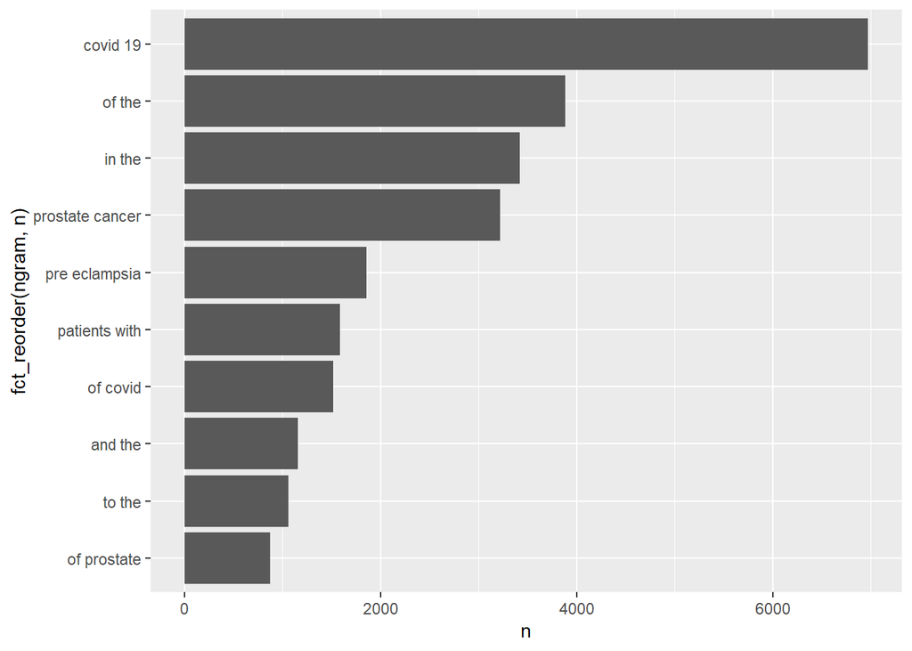

```r
covid %>%
  unnest_ngrams(ngram, abstract, n=2) %>%
  count(ngram, sort = TRUE) %>%
  top_n(10, n)%>%
  ggplot(aes(n, fct_reorder(ngram, n))) +
  geom_col()
```

Based on the tokenized abstracts bigram above, the 10 most frequent bigrams are shown. The most frequent bigram is covid 19, which is somewhat expected.

## 3. Calculate TF-IDF value

```r
covid %>%
  unnest_tokens(document, abstract) %>%
  anti_join(stop_words, by = c("document" = "word")) %>%
  count(document, sort = TRUE)%>%
  bind_tf_idf(document,document, n)%>%
  arrange(desc(tf_idf))
```

```
## # A tibble: 19,978 x 5
##    document         n    tf   idf tf_idf
##    <chr>        <int> <dbl> <dbl>  <dbl>
##  1 covid         7275     1  9.90   9.90
##  2 19            7080     1  9.90   9.90
##  3 patients      4674     1  9.90   9.90
##  4 cancer        3999     1  9.90   9.90
##  5 prostate      3832     1  9.90   9.90
##  6 disease       2574     1  9.90   9.90
##  7 pre           2165     1  9.90   9.90
##  8 eclampsia     2005     1  9.90   9.90
##  9 preeclampsia  1863     1  9.90   9.90
## 10 treatment     1841     1  9.90   9.90
## # ... with 19,968 more rows
```